# homework4

陳羽渢/B04703090/財金二

5/16/2017

# 高中生體適能（柔軟度、肌耐力、瞬發力、心肺耐力）各項間的關係

```r
#載入套件
library(knitr)
library(ggplot2)
library(coefplot)
require(lattice)
require(MASS)
require(heplots)
require(corrplot)
require(effects)
library(lm.beta)
#為了消除各縣市人數的差異，我們只採用比例來看
#讀取資料、預覽

raw<-read.table(file="sport103 2.csv",encoding = "big5",sep = ",",header = TRUE)
kable(head(raw,3))
```

| 縣市 | 性別 | 柔軟度待加強比率 | 柔軟度中等比率 | 柔軟度銅牌比率 | 柔軟度銀牌比率 | 柔軟度金牌比率 | 肌耐力待加強比率 | 肌耐力中等比率 | 肌耐力銅牌比率 | 肌耐力銀牌比率 | 肌耐力金牌比率 | 瞬發力待加強比率 | 瞬發力中等比率 | 瞬發力銅牌比率 | 瞬發力銀牌比率 | 瞬發力金牌比率 | 心肺耐力待加強比率 | 心肺耐力中等比率 | 心肺耐力銅牌比率 | 心肺耐力銀牌比率 | 心肺耐力金牌比率 | 總評待加強比率 | 總評中等比率 | 總評銅牌比率 | 總評銀牌比率 | 總評金牌比率 |
| --- | --- | --- | --- | --- | --- | --- | --- | --- | --- | --- | --- | --- | --- | --- | --- | --- | --- | --- | --- | --- | --- | --- | --- | --- | --- | --- |
| 新北市 | 男 | 16.38 | 25.41 | 28.05 | 11.31 | 18.86 | 15.28 | 16.23 | 24.15 | 12.18 | 32.16 | 21.19 | 24.71 | 23.76 | 10.56 | 19.78 | 20.37 | 25.27 | 25.60 | 10.70 | 18.06 | 45.12 | 32.85 | 16.81 | 3.33 | 1.89 |
| 新北市 | 女 | 16.46 | 26.52 | 24.82 | 10.59 | 21.62 | 11.02 | 18.20 | 25.01 | 12.59 | 33.18 | 16.92 | 24.45 | 27.89 | 11.74 | 19.00 | 19.88 | 24.05 | 25.63 | 11.01 | 19.44 | 42.58 | 35.20 | 16.63 | 3.52 | 2.07 |
| 宜蘭縣 | 男 | 23.53 | 32.94 | 25.88 | 7.06 | 10.59 | 17.65 | 9.41 | 14.12 | 10.59 | 48.24 | 22.09 | 23.26 | 25.58 | 10.47 | 18.60 | 30.77 | 21.54 | 21.54 | 10.77 | 15.38 | 64.06 | 17.19 | 14.06 | 3.13 | 1.56 |

```r
#轉換成可用的形式
allType<-names(raw)
typeId<-c(3:27)
newTable<-data.frame()
for(nid in c(1:44))
{
  city <- as.matrix(rep(raw$縣市[nid], length(raw[nid,typeId])))
  gender <- as.matrix(rep(raw$性別[nid], length(raw[nid,typeId])))
  percentage <- as.matrix(as.numeric(raw[nid,typeId]))
  type <- as.matrix(as.character(allType[typeId]))
  temp <- cbind(city, gender,percentage, type)
  newTable <- rbind(newTable, temp)
}
names(newTable) <- c("city","gender", "percentage", "type")
#將percentage轉為數值
newTable$percentage<-as.numeric(as.character(newTable$percentage))
kable(head(newTable,3))
```

| city | gender | percentage | type |
| --- | --- | --- | --- |
| 新北市 | 男 | 16.38 | 柔軟度待加強比率 |
| 新北市 | 男 | 25.41 | 柔軟度中等比率 |
| 新北市 | 男 | 28.05 | 柔軟度銅牌比率 |

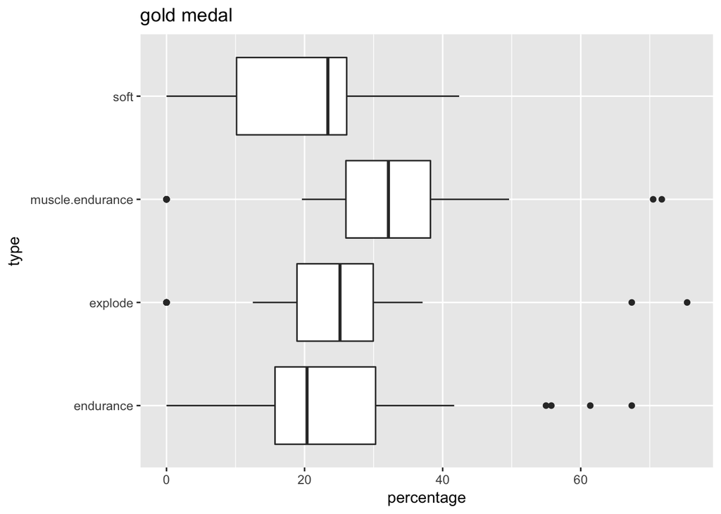

```r
#取出各項目金牌的比率做觀察
a<-newTable[type=="柔軟度金牌比率",]
a$type<-c("soft")
b<-newTable[type=="肌耐力金牌比率",]
b$type<-c("muscle.endurance")
c<-newTable[type=="瞬發力金牌比率",]
c$type<-c("explode")
d<-newTable[type=="心肺耐力金牌比率",]
d$type<-c("endurance")
goldmedal<-rbind(a,b,c,d)

ggplot(data = goldmedal, aes(x = type, y = percentage)) + geom_boxplot() + coord_flip() +
 labs( y = 'percentage', x = 'type',
       title = 'gold medal')
```

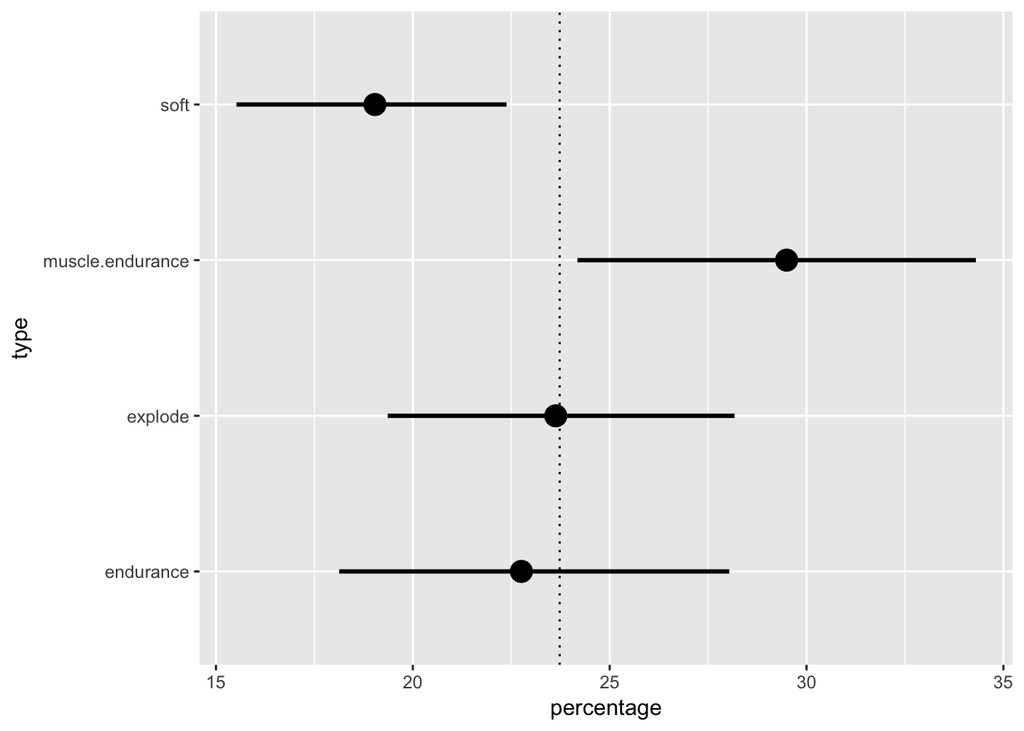

```r
#進一步加上信賴區間來看他們之間的關係
ggplot(data = goldmedal,
       aes(x = type, y = percentage)) +
  stat_summary(fun.data = 'mean_cl_boot', size = 1) +
  geom_hline(yintercept = mean(goldmedal$percentage) ,
             linetype = 'dotted') +
  labs(x = 'type', y = 'percentage') +
  coord_flip()
```

我們可以發現到肌耐力獲得金牌的比例明顯較其他三者來得高，而柔軟度則是相對較少的。另外，我們可以發現爆發力跟心肺耐力的比例相當接近，因此進一步比較這兩者之間是否有所關聯。我想接著探討哪些會影響爆發力。

```r
#重新整理表單形式
a1<-newTable[type=="瞬發力金牌比率",]
a1$type<-c("explode")
a1<-cbind(a1,medal=c("gold"))
a2<-newTable[type=="瞬發力銀牌比率",]
a2$type<-c("explode")
a2<-cbind(a2,medal=c("silver"))
a3<-newTable[type=="瞬發力銅牌比率",]
a3$type<-c("explode")
a3<-cbind(a3,medal=c("copper"))
a4<-newTable[type=="瞬發力中等比率",]
a4$type<-c("explode")
a4<-cbind(a4,medal=c("middle"))
a5<-newTable[type=="瞬發力待加強比率",]
a5$type<-c("explode")
a5<-cbind(a5,medal=c("more effort"))
b1<-newTable[type=="心肺耐力金牌比率",]
b1$type<-c("endurance")
b2<-newTable[type=="心肺耐力銀牌比率",]
b2$type<-c("endurance")
b3<-newTable[type=="心肺耐力銅牌比率",]
b3$type<-c("endurance")
b4<-newTable[type=="心肺耐力中等比率",]
b4$type<-c("endurance")
b5<-newTable[type=="心肺耐力待加強比率",]
b5$type<-c("endurance")
c1<-newTable[type=="肌耐力金牌比率",]
c1$type<-c("muscle.endurance")
c2<-newTable[type=="肌耐力銀牌比率",]
c2$type<-c("muscle.endurance")
c3<-newTable[type=="肌耐力銅牌比率",]
c3$type<-c("muscle.endurance")
c4<-newTable[type=="肌耐力中等比率",]
c4$type<-c("muscle.endurance")
c5<-newTable[type=="肌耐力待加強比率",]
c5$type<-c("muscle.endurance")
d1<-newTable[type=="柔軟度金牌比率",]
d1$type<-c("soft")
d2<-newTable[type=="柔軟度銀牌比率",]
d2$type<-c("soft")
d3<-newTable[type=="柔軟度銅牌比率",]
d3$type<-c("soft")
d4<-newTable[type=="柔軟度中等比率",]
d4$type<-c("soft")
d5<-newTable[type=="柔軟度待加強比率",]
d5$type<-c("soft")
compare1<-rbind(a1,a2,a3,a4,a5)
compare2<-rbind(b1,b2,b3,b4,b5)
compare2<-compare2[,3:4]
compare3<-rbind(c1,c2,c3,c4,c5)
compare3<-compare3[,3:4]
compare4<-rbind(d1,d2,d3,d4,d5)
compare4<-compare4[,3:4]
compare<-cbind(compare1,compare2,compare3,compare4)
colnames(compare)<-c("city","gender","percentage1","type1","medal","percentage2"," type2","percentage3"," type3","percentage4"," type4")
#不同級別與瞬發力影響
anova(m1 <- lm(percentage1 ~ medal, data = compare))
```

```
## Analysis of Variance Table
##
## Response: percentage1
##            Df  Sum Sq Mean Sq F value    Pr(>F)
## medal       4  6019.5 1504.88  13.672 5.991e-10 ***
## Residuals 215 23665.2  110.07
## ---
## Signif. codes:  0 '***' 0.001 '**' 0.01 '*' 0.05 '.' 0.1 ' ' 1
```

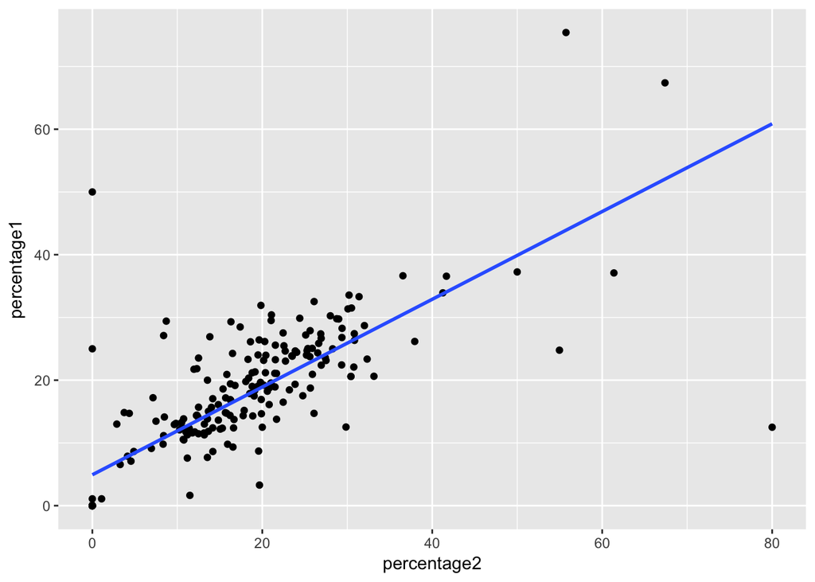

```r
#比較瞬發力和心肺耐力
ggplot(data = compare,
  aes( y = percentage1, x = percentage2)) +
  geom_point() +
  stat_smooth(method = 'lm', se = F)
```

從整體的散佈圖來看兩者之間的確存在一定的關係，那麼各個牌別的分佈又是如何，所以我們接著將其分開看

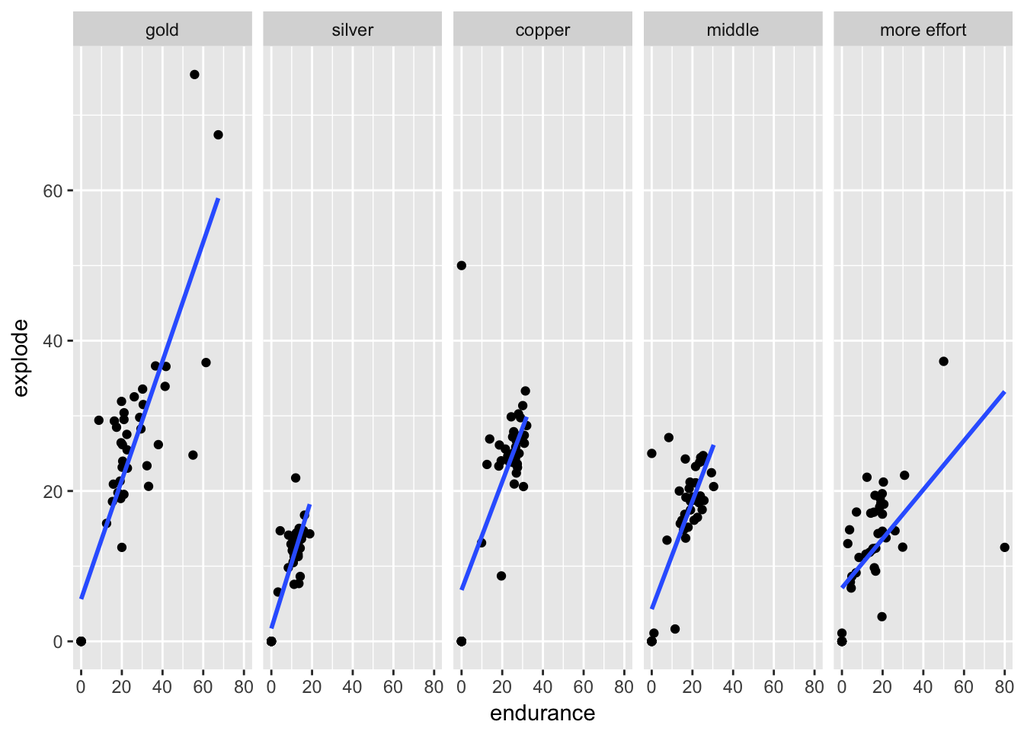

```r
#各級別瞬發力和心肺耐的關係
ggplot(data = compare,
  aes(group = medal,
    y = percentage1, x = percentage2)) +
  geom_point() +
  stat_smooth(method = 'lm', se = F)+
  facet_grid( .~ medal) +
  labs(x = 'endurance', y = 'explode')
```

我們可以發現除了待努力之外，其他級別的相關性（斜率）是差不多的

```r
# anova檢定 （瞬發力和心肺耐力）
#將心肺耐力加進模型
anova(m2 <- update(m1, . ~ . +
            percentage2, data = compare))
```

```
## Analysis of Variance Table
##
## Response: percentage1
##              Df  Sum Sq Mean Sq F value    Pr(>F)
## medal         4  6019.5  1504.9  29.999 < 2.2e-16 ***
## percentage2   1 12930.1 12930.1 257.757 < 2.2e-16 ***
## Residuals   214 10735.1    50.2
## ---
## Signif. codes:  0 '***' 0.001 '**' 0.01 '*' 0.05 '.' 0.1 ' ' 1
```

```r
#或許不是級別而是心肺耐力造成瞬發力不同
anova(m3 <- update(m2, . ~ . -
            medal,  data = compare))
```

```
## Analysis of Variance Table
##
## Response: percentage1
##              Df Sum Sq Mean Sq F value    Pr(>F)
## percentage2   1  17692   17692  321.61 < 2.2e-16 ***
## Residuals   218  11992      55
## ---
## Signif. codes:  0 '***' 0.001 '**' 0.01 '*' 0.05 '.' 0.1 ' ' 1
```

```r
#將結果放在一個list中
res_lm <- lapply(list(m1, m2, m3), summary)
#比較在控制心肺耐力下，級別影響瞬發力的效果
(res_lm[[2]]$r.sq - res_lm[[3]]$r.sq)/res_lm[[2]]$r.sq
```

```
## [1] 0.06635358
```

```r
anova(m3, m2)
```

```
## Analysis of Variance Table
##
## Model 1: percentage1 ~ percentage2
## Model 2: percentage1 ~ medal + percentage2
##   Res.Df   RSS Df Sum of Sq      F   Pr(>F)
## 1    218 11992
## 2    214 10735  4    1257.4 6.2663 8.71e-05 ***
## ---
## Signif. codes:  0 '***' 0.001 '**' 0.01 '*' 0.05 '.' 0.1 ' ' 1
```

```r
#比較在控制級別下，心肺耐力影響瞬發力的效果
(res_lm[[2]]$r.sq - res_lm[[1]]$r.sq)/res_lm[[1]]$r.sq
```

```
## [1] 2.14803
```

```r
anova(m1, m2)
```

```
## Analysis of Variance Table
##
## Model 1: percentage1 ~ medal
## Model 2: percentage1 ~ medal + percentage2
##   Res.Df   RSS Df Sum of Sq      F    Pr(>F)
## 1    215 23665
## 2    214 10735  1     12930 257.76 < 2.2e-16 ***
## ---
## Signif. codes:  0 '***' 0.001 '**' 0.01 '*' 0.05 '.' 0.1 ' ' 1
```

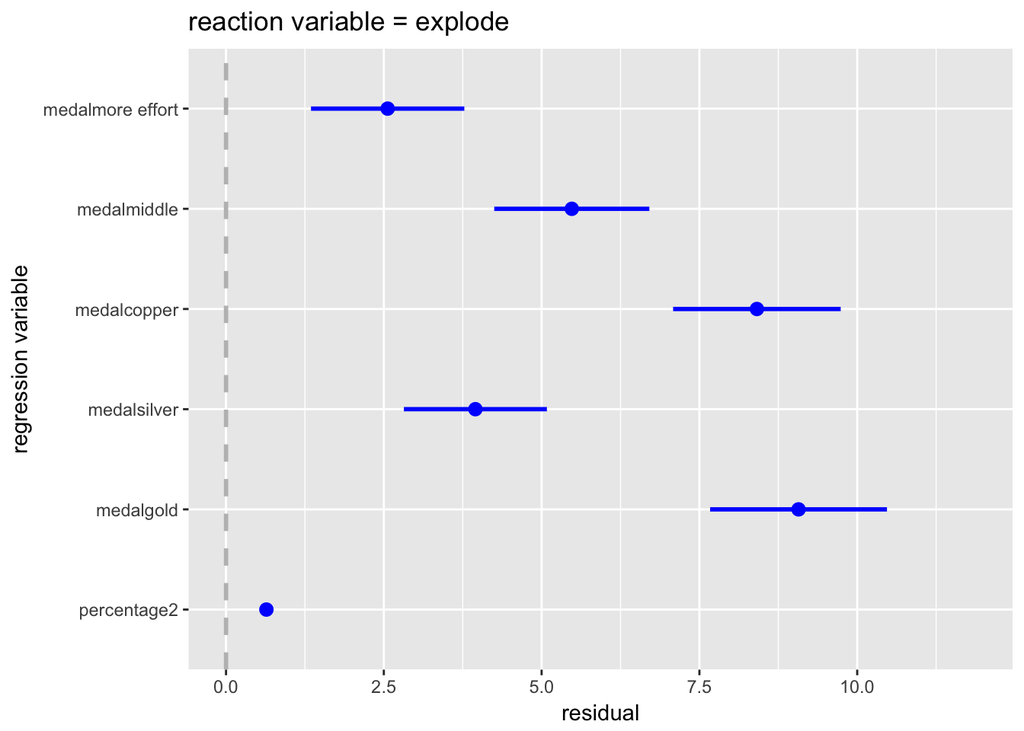

```r
#畫效果
#將截距去除
m2 <- lm(percentage1 ~ percentage2+medal-1,
  data = compare)
coefplot(m2, xlab = 'residual', ylab = 'regression variable', title = 'reaction variable = explode')
```

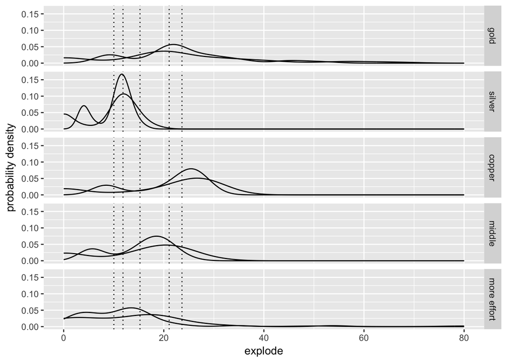

```r
#把資料與迴歸分析的預測值、殘差與影響度放進資料
fit_m2 <- data.frame(compare[, c(3, 5, 6)], fitted = fitted(m2), resid = resid(m2),
  infl = influence(m2)$hat )
#疊合真實觀測值預測值的直方圖，依級別
ggplot(data = fit_m2, aes(x = percentage2, group = medal )) +
  stat_density(geom = 'path', position = 'identity')  +

  stat_density(geom = 'path', position = 'identity', aes(x = fitted))+
  geom_vline(xintercept = c(with(compare, tapply(percentage1,medal, mean))), linetype = 'dotted')+
  facet_grid(medal ~ .) +
  labs(x = 'explode', y = 'probability density')
```

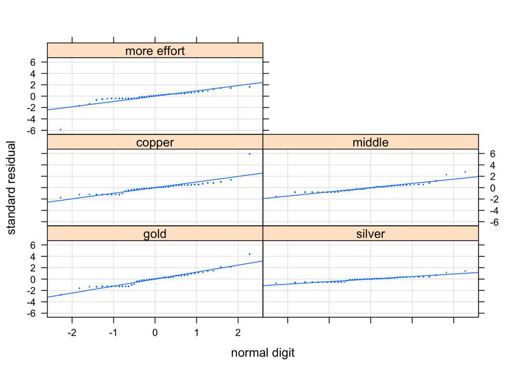

```r
#看看殘差的 Q-Q 圖，依級別。檢視常態假設

qqmath(~ scale(resid) | medal, data = fit_m2, type = c('p', 'g', 'r'),xlab = 'normal digit', ylab = 'standard residual', layout= c(2, 3),pch = '.', cex = 2)
```

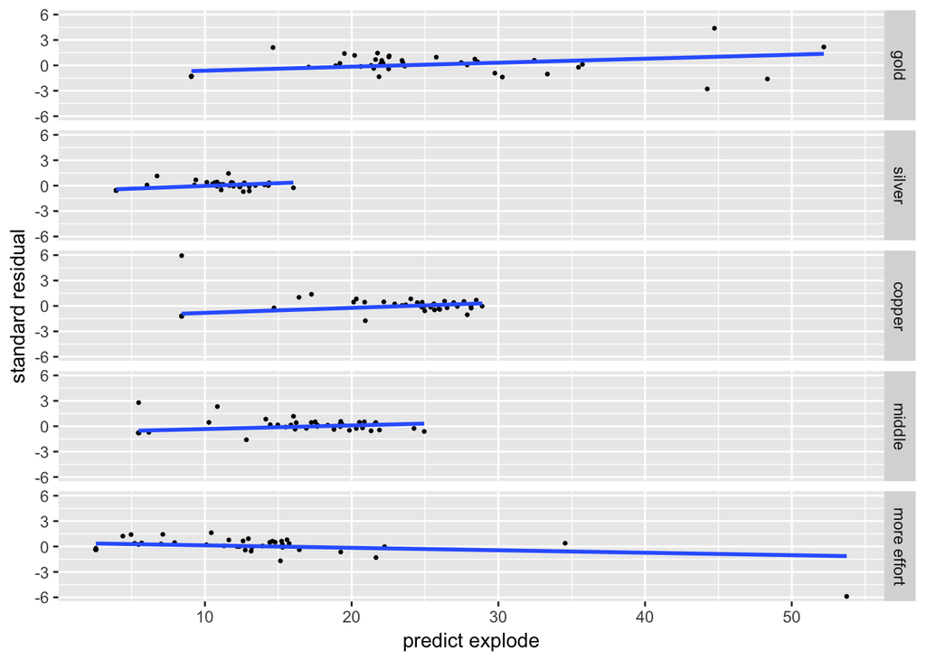

```r
#畫預測值與殘差的散佈圖，檢查線性與等分散假設

ggplot(data = fit_m2, aes(x = fitted, y = scale(resid), group = medal )) +
  geom_point(pch = 20, size = 1) +
  stat_smooth(method = 'rlm', se = F) +
  facet_grid(medal ~ .) +
  labs(x = 'predict explode', y = 'standard residual')
```

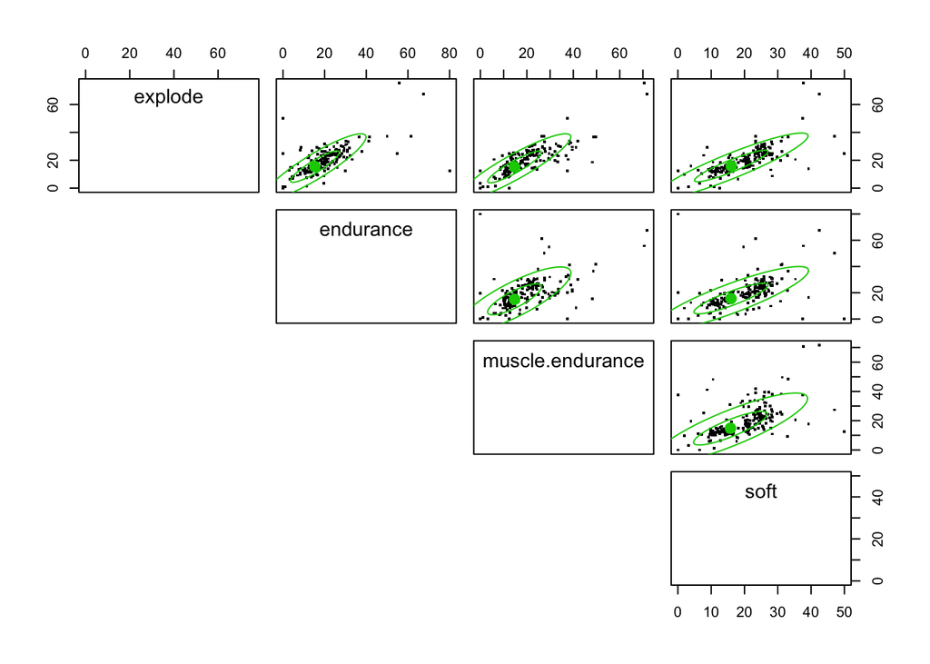

```r
#底下要呈現多個連續解釋變項時的情形
#看看四個指標之間的關聯，先取出分別的資料
related<-compare[c("percentage1","percentage2","percentage3","percentage4")]
colnames(related)<-c("explode","endurance","muscle.endurance","soft")
#呈現兩兩散佈圖

scatterplotMatrix(~ explode+endurance+muscle.endurance+soft,data=related,pch = '.', cex = 3, smooth = FALSE, reg.line = FALSE, ellipse = TRUE,diagonal = 'none',lower.panel = NULL)
```

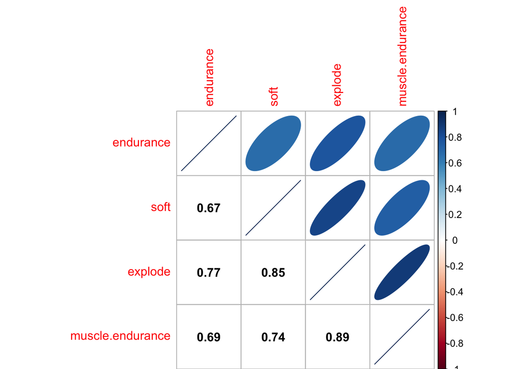

```r
corrplot(cor(related), method = 'ellipse', order = 'hclust', addrect = 4,type = 'upper', tl.pos = 'tp')
corrplot(cor(related), add = TRUE, type = 'lower', method = 'number',
  order = 'hclust', col = 'black', diag = FALSE, tl.pos = 'n', cl.pos = 'n')
```

由上表可以發現各項指標幾乎都是息息相關的，尤其是肌耐力與瞬發力的關係最為顯著，令人意外的是，柔軟度與瞬發力相關性也不小，但其與其他兩者相關性就較小

```r
#放進三個解釋變項
summary(m4 <- lm(explode~endurance+muscle.endurance+soft,data=related))
```

```
##
## Call:
## lm(formula = explode ~ endurance + muscle.endurance + soft, data = related)
##
## Residuals:
##      Min       1Q   Median       3Q      Max
## -12.1155  -1.6282   0.3033   1.6570  19.2318
##
## Coefficients:
##                  Estimate Std. Error t value Pr(>|t|)
## (Intercept)      -0.30327    0.49810  -0.609    0.543
## endurance         0.17810    0.03053   5.833 1.97e-08 ***
## muscle.endurance  0.45350    0.03438  13.191  < 2e-16 ***
## soft              0.38694    0.03918   9.877  < 2e-16 ***
## ---
## Signif. codes:  0 '***' 0.001 '**' 0.01 '*' 0.05 '.' 0.1 ' ' 1
##
## Residual standard error: 3.965 on 216 degrees of freedom
## Multiple R-squared:  0.8856, Adjusted R-squared:  0.884
## F-statistic: 557.3 on 3 and 216 DF,  p-value: < 2.2e-16
```

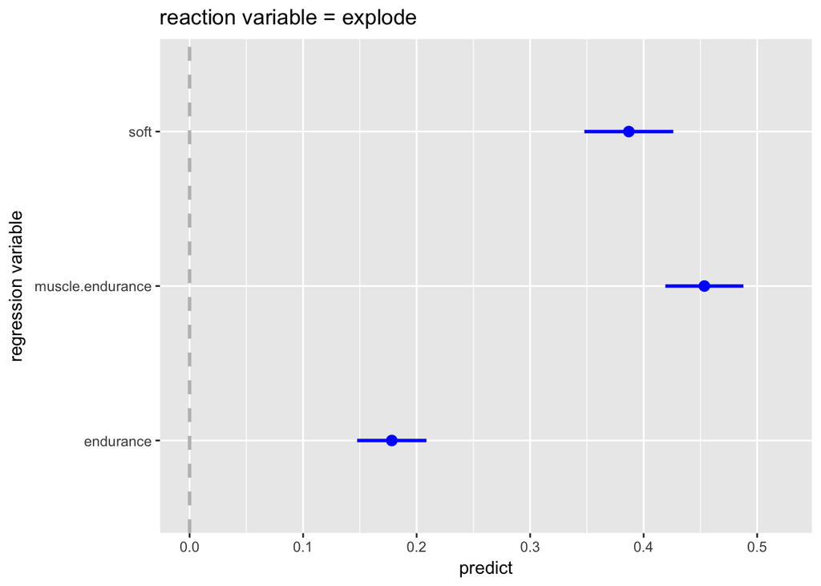

```r
#看效果
coefplot(m4, predictors = c("endurance","muscle.endurance","soft"),
  xlab = 'predict', ylab = 'regression variable', title = 'reaction variable = explode')
```

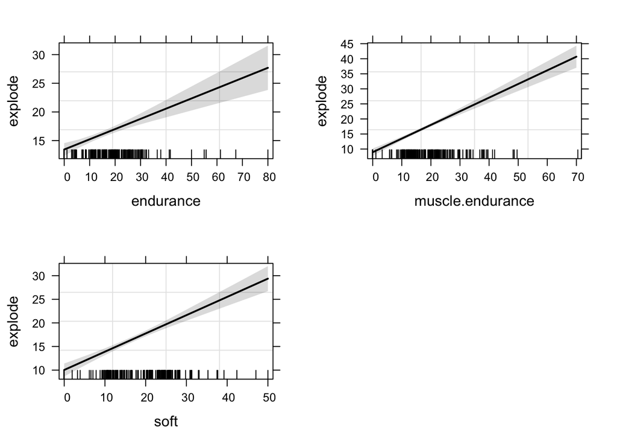

```r
#看效果(計算標準化迴歸係數)
plot(allEffects(m4), main = '', grid = T)
```

```r
summary(lm.beta(m4))
```

```
##
## Call:
## lm(formula = explode ~ endurance + muscle.endurance + soft, data = related)
##
## Residuals:
##      Min       1Q   Median       3Q      Max
## -12.1155  -1.6282   0.3033   1.6570  19.2318
##
## Coefficients:
##                  Estimate Standardized Std. Error t value Pr(>|t|)
## (Intercept)      -0.30327      0.00000    0.49810  -0.609    0.543
## endurance         0.17810      0.19663    0.03053   5.833 1.97e-08 ***
## muscle.endurance  0.45350      0.48702    0.03438  13.191  < 2e-16 ***
## soft              0.38694      0.35687    0.03918   9.877  < 2e-16 ***
## ---
## Signif. codes:  0 '***' 0.001 '**' 0.01 '*' 0.05 '.' 0.1 ' ' 1
##
## Residual standard error: 3.965 on 216 degrees of freedom
## Multiple R-squared:  0.8856, Adjusted R-squared:  0.884
## F-statistic: 557.3 on 3 and 216 DF,  p-value: < 2.2e-16
```